# 心理ネットワークアプローチ

国里愛彦

## 目次

- 心理ネットワークアプローチ
- 横断データのネットワーク分析
- ネットワークシミュレーション
- 縦断データのネットワーク分析
- 微分方程式によるシミュレーション

## 国里愛彦（くにさと よしひこ）

- 専修大学人間科学部心理学科 教授
- 専門：計算論的精神医学、認知行動療法
- 関心：うつや不安の発生・維持メカニズム、心理療法の作用メカニズム、個性記述
- COI開示：本発表では国里の関わった訳書や論文の内容を扱うが、特定企業との利益相反はない

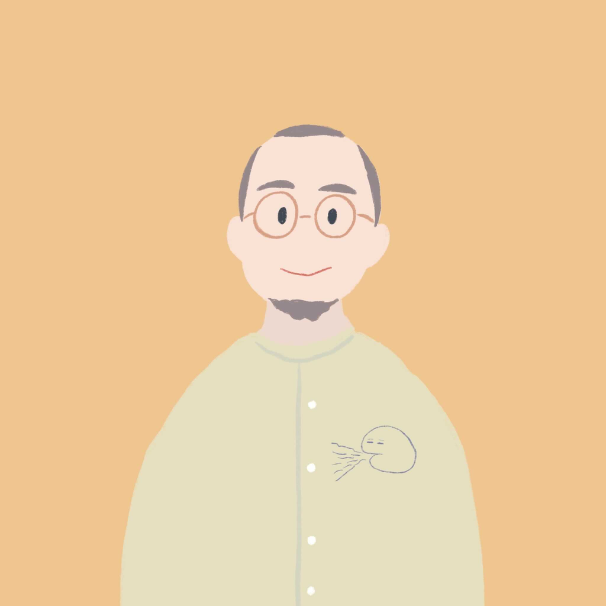

# 心理ネットワークアプローチ

## プロセス・ベースド・セラピー

- ステファン・G・ホフマンとスティーブン・C・ヘイズが提唱した心理療法の統合的枠組み
- 変化のプロセスに焦点を当て、統合的な視点を提供する。拡張進化論メタモデル、ネットワークモデルが特徴
- [『プロセス・ベースド・セラピーをまなぶ』](https://amzn.to/4otYJQH)(Hofmann et al. 2023)

[figure not shown]

## PBTとネットワーク

- PBTでは、クライエントの苦悩に対して動的・個性記述的にアプローチするために、ネットワークモデルを採用する。苦悩に関わる要素を繋いでネットワークにして、介入ターゲットを探る

[figure not shown]

## 実践にネットワークモデルを適用

- 面接室内では、クライエントと対話しつつ、苦悩のネットワークモデルを描いていく（ナラティブに基づく悪循環の可視化）
- PBTでも扱われているが、スマートフォンなどのアプリを用いた経験サンプリング法などで、日常生活の苦悩に関わる要素を測定することも可能になってきている
- 測定されたデータをもとに、データ駆動的にネットワークを描くことはできないか？

→心理ネットワークアプローチ

## 心理ネットワークアプローチ

- アムステルダム大学のPsychological Methodsの研究者による心理ネットワークアプローチの書籍
- [『心理ネットワークアプローチ入門：行動科学者と社会科学者のためのガイド』](https://amzn.to/4nNJTTX)(Isvoranu et al. 2022)

[figure not shown]

## 心理ネットワークアプローチ

- 私たちの心（構成概念）を、複数のコンポーネントが相互作用してできるネットワークとみなす考え方(Borsboom et al. 2022)
- CBTモデルのように、コンポーネント間の相互作用が前提となるものに適用しやすい
- 現象をコンポーネントに分解して検討するのではなく、システムとしてみる
- ネットワークの構造がシステムの挙動と強く結びついていると考える

## 精神病理とネットワーク

- 精神障害には本質があり、それが各症状を引き起こしているという考え（潜在変数モデル）ではなく、症状同士が相互作用して精神障害を形成している（ネットワークモデル）と考える
- 例えば、うつ病では、不眠が疲労を引き起こし、疲労が集中力の低下を引き起こし、集中力の低下が自己評価の低下を引き起こすような連鎖がある
- 症状間の相互作用から病を理解していくことは、CBTの介入を考えていく上でも有用かもしれない

## 精神病理とネットワーク

- DSM-IVの諸症状のネットワーク(Boschloo et al. 2015)。症状同士が相互作用し、障害ごとにクラスターを作っているが完全に境界があるわけでない

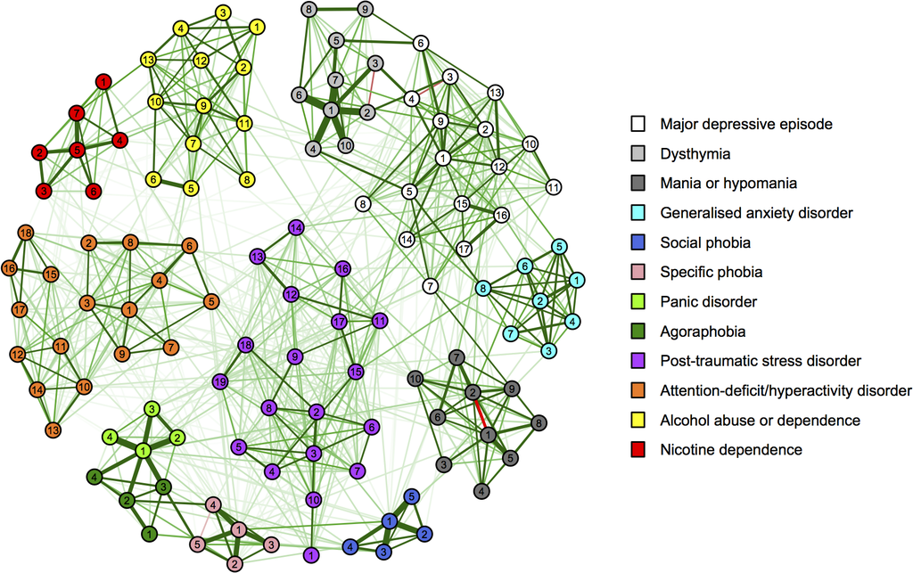

## 心理ネットワークモデルとは？

- 多変量確率分布を用いて、心理変数間のネットワーク構造を描写するもの(Epskamp, Borsboom, and Fried 2018)
- ネットワークは、観察可能な変数を表すノード（円）と統計的関係を表すエッジ（線）から構成される

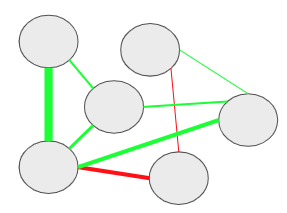

## 心理ネットワークの特徴

- エッジはデータから推定されるもの（重み付きネットワーク）

→サンプルサイズに影響されるので正確度・安定性を検討

→ネットワーク科学で扱われるグローバルなネットワーク特性(スモールワールド性など)は使えないので、ローカルなネットワーク特性(中心性指標)を用いる

## 有向・無向ネットワーク

- 有向ネットワークはエッジに方向性があるネットワーク(左図）、無向ネットワークは方向性がないネットワーク（右図）
- エッジの矢印は因果関係を示唆しているが、横断データではそれは難しい(→無向ネットワークの利用)

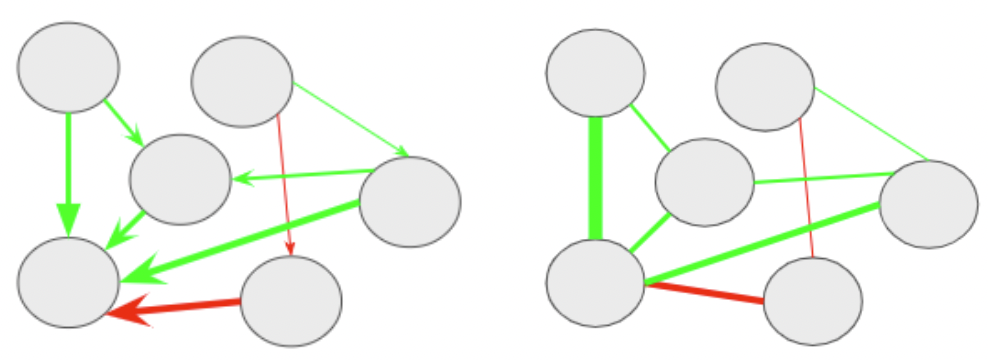

## エッジの見方

- **エッジの色** 符号を意味しており、青・緑の場合は正、赤の場合は負を表す
- **エッジの太さ** 全体のノードからの影響を考慮した時の２つのノード間の関係の強さ
- **エッジの長さ** エッジの強さの逆数。関係が強ければ強いほど短くなる

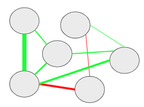

# 横断データのネットワーク分析

## 心理ネットワーク分析の手順

1. 統計的手法によってノード間のエッジを推定
2. 推定されたエッジをもとにネットワークを図示
3. ネットワーク特性の指標を検討
4. ネットワークの正確度・安定性を検討

## ペアワイズ・マルコフ確率場

- 無向ネットワークモデルの推定では、ペアワイズ・マルコフ確率場(pairwise Markov random field: PMRF)がよく使われる(Epskamp, Haslbeck, et al. 2022)
- 心理ネットワーク分析の主なペアワイズ・マルコフ確率場のモデルには、Gaussian graphical model (GGM)、Ising model、mixed graphical models (MGMs)がある

## ３つのペアワイズ・マルコフ確率場

1. **Gaussian graphical model (GGM)**: 連続変数のデータ(エッジの値は-1から1の範囲)
2. **Ising model**: 2値変数のデータ(エッジの値は-∞から∞の範囲)
3. **mixed graphical models (MGMs)**: 2値・順序・連続変数の混ざったデータ(エッジの値は-1から1の範囲)

## Gaussian graphical model(GGM)

- GGMでは、多変量正規分布を用いて、連続変数間のネットワークを推定する
- $\boldsymbol{Y}$ (ランダムに選んだ参加者からのn個の反応のベクトル)は、平均 $\boldsymbol{\mu}$ と分散共分散行列 $\boldsymbol{\Sigma}$ の多変量正規分布に従う

$$\boldsymbol{Y} \sim N\left(\boldsymbol{\mu}, \boldsymbol{\Sigma}\right)$$

## Gaussian graphical model(GGM)

- GGMでは、分散共分散行列 $\boldsymbol{\Sigma}$からその逆行列である精度行列 $\boldsymbol{K}$ を計算し( $\boldsymbol{K}=\boldsymbol{\Sigma}^{-1}$)、精度行列 $\boldsymbol{K}$ から偏相関行列を計算する
- 偏相関係数をエッジにしてネットワークをプロットする
- 分散共分散行列から偏相関行列を求める方法については、 国里愛彦 et al. (2023) を参照ください

## Ising model

- 元々は磁性体に関する統計力学的モデルだが、２値データのネットワークの記述に使える
- ２値反応のペアの同時確率をモデル化(Epskamp, Haslbeck, et al. 2022)

$$\operatorname{Pr}(\boldsymbol{Y}=\boldsymbol{y})=\frac{1}{Z} \exp \left(\sum_{i} y_{i} \tau_{i}+\sum_{<i, j>} y_{i} y_{j} \omega_{i j}\right)%$$

## Ising model

$$\operatorname{Pr}(\boldsymbol{Y}=\boldsymbol{y})=\frac{1}{Z} \exp \left(\sum_{i} y_{i} \tau_{i}+\sum_{<i, j>} y_{i} y_{j} \omega_{i j}\right)%$$

- $\tau_{i}$ は閾値(どっちの反応が出やすいか）、 $\omega_{i j}$ はノード間の反応の類似度。Zは確率の合計が１になるように機能
- Zの計算は、 $\boldsymbol{Y}$ の全ての可能性を考慮するので20変数以上の多変量推定は難しい(その場合、単変量推定する)

## Mixed graphical models(MGMs)

- 2値・順序・連続変数が混ざったデータに適用できる(Epskamp, Haslbeck, et al. 2022)
- データのタイプに合わせてノードごとに確率分布を適用(指数分布族: 正規分布、ポアソン分布、指数分布、多項分布）
- ノードごとに一般化線形モデルによって推定し、推定されたパラメータが最終モデルで統合される
- MGMsは、ペアワイズである必要もなくて、高次の交互作用を含めたmoderated network modelも検討できる

## モデル選択

- ネットワークは、エッジが１つもない空の「独立モデル」から、全てのノード間にエッジがある「飽和モデル」の間に、可能性のあるネットワークが大量にある(Blanken, Isvoranu, and Epskamp 2022)
- オッカムの剃刀に従い、パフォーマンスを下げないようにして、シンプルなモデルを選ぶ

## モデル選択

- 心理ネットワーク分析のモデル選択には以下の４つがある
1. しきい値(Thresholding)
2. 刈り込み(Pruning)
3. モデル探索(model search)
4. 正則化(regularization)

## しきい値(Thresholding)

- しきい値では、ある基準（p値, FDR(false discovery rate), 信用区間、ベイズファクター）に基づいて、エッジを除去する（エッジを0に設定）
- 基準以下のエッジを見せていないだけで影響は残る

## 刈り込み(Pruning)

- 刈り込みでは、ある基準（p値, FDR(false discovery rate), 信用区間、ベイズファクター）に基づいて、除去した上で（エッジを0に設定）、**再推定**する
- 再推定するので、基準以下のエッジを0としたときのネットワークが推定される

## モデル探索(model search)

- 可能なネットワークを反復的に探索して最もデータフィットしたモデルを選ぶ（AIC, BIC, EBICなどの情報量規準を用いる)
- 独立モデルからエッジを足していくステップアップ、飽和モデルからエッジを削っていくステップダウンがある
- よく使われるggmModSelectアルゴリズムでは、正則化推定（後述）後に、ステップアップとステップダウンを組み合わせて、情報量基準が最小になるモデルを探索する

## 正則化(regularization)

- モデルの複雑さに罰則をかけて、ネットワークを疎(sparse)にする。影響力が弱いエッジはゼロに近づき単純化できる
- LASSO(least absolute shrinkage and selection operator)の一種のGraphical LASSOを使う。罰則の強さの調整は、cross-validation(CV)やEBICを使う

## GGMでのモデル選択の推奨

- Isvoranu and Epskamp (2021) のシミュレーション研究に基づく推奨
1. サンプルサイズが300の場合、ネットワーク構造の発見には、正則化が好ましい
2. サンプルサイズが1000の場合、ネットワーク構造や強いエッジに興味があるなら正則化、特定のエッジに関心があるならモデル探索が好ましい
3. サンプルサイズが5000の場合、真のネットワークの探索には、モデル探索が好ましい

## Ising modelとMGMsでのモデル選択の推奨

- Isingモデルの場合、小中サンプルサイズでは正則化手法が見やすく、大サンプルサイズでは非正則化手法も使える(Blanken, Isvoranu, and Epskamp 2022)
- MGMsで使えるのは正則化手法のみ(Blanken, Isvoranu, and Epskamp 2022)

## 順序・非正規変数での注意点

- 順序変数ではポリコリック相関を使うが、小サンプルサイズでは不安定になる（psychonetricsパッケージの推定法やBGGMパッケージを使う）(Blanken, Isvoranu, and Epskamp 2022)
- 正規分布していないデータの場合は、スピアマンの順位相関係数をGGMで用いる(Blanken, Isvoranu, and Epskamp 2022)

## サンプルサイズと欠測処理

- ノードは３０より少ないのが望ましく、できるだけサンプルサイズが大きいほうが望ましい(Isvoranu and Epskamp 2021)
- ネットワークの構造を調べるより、特定のエッジに焦点をしぼった方が大きなサンプルサイズが必要
- bootnetパッケージでは欠測値除去が必要だが、psychonetricsパッケージでは完全情報最尤推定法が使える(estimator = “FIML”)

## エッジの解釈法

- PMRFのエッジは、２変数以外の影響も考慮した２変数の関係を表す（ネットワーク全体の影響を考慮する）
- エッジの解釈としては以下の２つがある

(1)**予測可能性の示唆**: 他の変数の影響を考慮しても、ある変数から別の変数が予測できる可能性がある

(2)**因果関係の可能性の示唆**: 因果の方向性は不明だが、そのエッジにはなんらかの因果的な効果がある可能性はある(逆にいうと、強い理論的予測による仮説検証結果のような解釈はしない)

## エッジの正確度(accuracy)

- 推定されたエッジはサンプルやサンプルサイズの影響をうけるのでエッジの正確度を検討(Epskamp, Borsboom, and Fried 2018)
- ブートストラップ法による信頼区間をプロットすることでエッジの重みの正確度を検討する(有意性の検討には使わない)

## ノードの中心性指標

- **Strength**:あるノードがつながっている全てのエッジの強さの合計。あるノードの全体に対する影響力を示している
- **Closeness**: あるノードと他の全てのノード間の最短経路長の合計の逆数。あるノードがどのくらい間接的な影響を含めて他のノードとつながっているのかを示している
- **Betweenness**: 2つのノード間の最短経路上に、あるノードが何回あるのかを示している。あるノードが2つのノードの経路上でどのくらい重要かを示している

## 中心性指標の安定性(Stability)

- 推定されたエッジはサンプルやサンプルサイズの影響をうけるので中心性指標の安定性(Stability)を検討(Epskamp, Borsboom, and Fried 2018)
- データのサブセットを用いた場合の中心性指標の安定性を検討 (サンプルサイズを小さくしても安定するか検討、CS係数が0.25未満は不適切であり0.5を超えている必要があるという基準がある。ただ、絶対的な基準ではない)

## ネットワーク分析のための環境構築

### ローカルPCにRとRStudioをインストール

- ご自身のパソコンに(1)[Rのインストール](https://cran.r-project.org/)、(2)[RStudioのインストール](https://posit.co/download/rstudio-desktop/)、(3)Rパッケージのインストールをして、環境構築
- メリット：パソコンの計算資源を存分に活用できる。クラウドにアップロードできないデータも分析できる
- デメリット：Rパッケージを含めたインストールを自分で行わないといけない

## ネットワーク分析のための環境構築

### Posit Cloudの利用

- RStudioを開発しているPosit社が提供する[Posit Cloud](https://posit.cloud/) にアカウント登録して、環境構築
- メリット：すぐに使える。共有リンク機能で今回のWSで使う環境をすぐに用意できる（ファイルとインストールしたRパッケージなども共有できる）
- デメリット：無料版では計算資源に制限がある。クラウドにアップロードできないデータ分析はできない

## Posit Cloudの登録方法(1)

- [Posit Cloud](https://posit.cloud/)にアクセスして、右上の「Sign Up」をクリック

[figure not shown]

## Posit Cloudの登録方法(2)

- 今回はFree版を使う。Freeの「Learn more」をクリック

[figure not shown]

## Posit Cloudの登録方法(3)

- 「Sign Up」をクリック

[figure not shown]

## Posit Cloudの登録方法(4)

- 「Sign Up」でメールアドレスなどで登録もできるが、Googleアカウントでログインが楽（「Log in with Google」をクリック）

[figure not shown]

## Posit Cloudの登録方法(5)

- 紐付けるGoogleアカウントを選択

[figure not shown]

## Posit Cloudの登録方法(6)

- Posit Cloudの利用規約や使われる情報について確認して問題がないなら、「次へ」をクリックする

[figure not shown]

## Posit Cloudの登録方法(7)

- Posit Cloudの登録が完了し、ログインできる

[figure not shown]

## Posit Cloudの共有リンク

- Posit Cloudでは、スペースを作成して、複数のユーザーでプロジェクトを共有できる（ファイルの共有だけでなく、Rパッケージをインストールした環境も共有できる）
- 今回のWS用のスペースを作ったので、以下のリンクをクリックして参加してください

[PsyNet WS用のリンク](https://posit.cloud/spaces/720243/join?access_code=yiabq_95yCZvtwIauJTdMSpjiKZS4GihLyg44uH-)

## Posit Cloudの使用方法(1)

- 「Join Space?」で「Yes」を選択する

[figure not shown]

## Posit Cloudの使用方法(2)

- Spacesに「psyNet-WS」が追加されれば成功。上の「Content」をクリックする

[figure not shown]

## Posit Cloudの使用方法(3)

- 「network」というRStudioのプロジェクトをクリック(読み込みに少し時間がかかる）

[figure not shown]

## Posit Cloudの使用方法(4)

- RStudioの画面が表示されれば成功。計算資源には制限があるが、普通のRStudioと同じようにクラウド上で解析ができる

[figure not shown]

## 用いるRパッケージ

- [tidyverse](https://tidyverse.org/):dplyr（データ操作）や ggplot2（可視化）などデータ処理全般に使えるパッケージ
- [qgraph](https://cran.r-project.org/web/packages/qgraph/index.html):ネットワーク推定(GGM)とプロット。qgraphをインストールすると、plot()関数にネットワーク推定結果のオブジェクトが入った時に、ネットワーク図をプロットできるようになる
- [bootnet](https://cran.r-project.org/web/packages/bootnet/index.html): ネットワーク推定(GGM & Isingモデル)、ネットワークの正確度と安定性の検討
- [psychonetrics](https://cran.r-project.org/web/packages/psychonetrics/index.html)：より洗練化した書き方でネットワーク推定(GGM & Isingモデル)

## 用いるRパッケージ

- [networktools](https://cran.r-project.org/web/packages/networktools/index.html): EI (Expected Influence) やブリッジ中心性を計算する
- [IsingFit](https://cran.r-project.org/web/packages/IsingFit/index.html):2値データの心理ネットワーク分析
- [MPsychoR](https://cran.r-project.org/web/packages/MPsychoR/index.html) :書籍 “Modern Psychometrics with R” のサプリメント・パッケージ。今回はRogersデータセット
- [mgm](https://cran.r-project.org/web/packages/mgm/index.html):ネットワーク推定(MGMs,今回は用いないが、２値・順序・連続変数の混ざったデータに適用できる）

## Rパッケージのインストール

- **Posit Cloudで共有リンクを使っている場合は、インストール不要**。ローカルPCのR＆RStudioを使っている場合は、以下をRStudioのConsoleにコピペして実行

```r
install.packages("tidyverse", dependencies = TRUE)
install.packages("bootnet", dependencies = TRUE)
install.packages("qgraph", dependencies = TRUE)
install.packages("psychonetrics", dependencies = TRUE)
install.packages("networktools", dependencies = TRUE)
install.packages("NetworkComparisonTest", dependencies = TRUE)
install.packages("MPsychoR", dependencies = TRUE)
install.packages("IsingFit", dependencies = TRUE)
install.packages("graphicalVAR", dependencies = TRUE)
# WSで使うRパッケージでGitHub経由でインストールするものをR-Universe経由でインストール
install.packages("psynetsim", repos = c("https://ykunisato.r-universe.dev", "https://cran.r-project.org"))
install.packages("PanicModel", repos = c("https://ykunisato.r-universe.dev", "https://cran.r-project.org"))
```

## Quartoの実行方法

1. 「Files」の「PsyNet.qmd」をクリックして開く
2. 「PsyNet.qmd」内のコード実行は緑色の三角形をクリック（一気に実行する時は「Render」だが、今回は１つずつ緑色の三角形をクリックして実行）

[figure not shown]

## Rパッケージの読み込み

- 以降の横断データの心理ネットワーク分析では、以下のRパッケージを使う

```r
# データ処理・可視化のためのパッケージ
library(tidyverse)
# 心理ネットワーク分析のためのパッケージ
library(bootnet)
library(qgraph)
library(psychonetrics)
library(networktools)
library(NetworkComparisonTest)
library(IsingFit)
# データセット用のパッケージ
library(MPsychoR)
```

## データについて

- MPsychoRパッケージのRogersデータセット
- McNally et al. (2017) のうつ病を併発した強迫症患者408名のデータ(Rogers Memorial Hospitalで集められたデータだから、「Rogers」)
- データセットには、うつ症状を測るQuick Inventory of Depressive Symptomatology (QIDS-SR)と強迫症状を測るYale-Brown Obsessive Compulsive Scale - self-report (Y-BOCS-SR)

## QIDSの16項目

- QIDSの16項目（英字は変数名）。なお、QIDSの日本語版は、[こちら](https://www.mhlw.go.jp/bunya/shougaihoken/kokoro/dl/02.pdf)で確認できる
1. onset: 入眠困難
2. middle: 中途覚醒
3. late: 早朝覚醒
4. hypersom: 過眠
5. sad: 悲しみ
6. decappetite: 食欲減退
7. incappetite: 食欲増進
8. weightloss: 体重減少
9. weightgain: 体重増加
10. concen: 集中困難
11. guilt: 罪悪感と自責感
12. suicide: 自殺念慮
13. anhedonia: アンヘドニア
14. fatigue: 倦怠感
15. retard: 精神運動制止
16. agitation: 精神運動焦燥

## データの読み込みと選択

- Rogersデータを読み込んでQIDSだけ選択する。colnames()で変数名をnode_namesに保存する

```r
data(Rogers)
data_dep <- Rogers %>%
  select(onset:agitation)

node_names <- colnames(data_dep)
head(data_dep)
```

```
  onset middle late hypersom sad decappetite incappetite weightloss weightgain
1     0      2    0        1   2           0           0          0          0
2     3      2    0        0   1           0           0          0          2
3     2      1    2        0   2           0           0          0          0
4     0      3    1        2   2           0           0          0          0
5     0      2    1        1   1           0           0          0          0
6     1      1    1        2   2           2           3          2          0
  concen guilt suicide anhedonia fatigue retard agitation
1      1     3       0         3       2      0         0
2      2     1       0         0       2      1         1
3      0     0       0         1       1      0         1
4      1     3       2         0       1      0         2
5      2     0       0         2       1      2         1
6      2     1       0         1       2      2         1
```

## モデル選択： しきい値

- bootnetパッケージのestimateNetwork()関数で、threshold(“sig”で有意かどうか)とalpha(有意水準)を指定する
- データは4件法で順序変数なので、「corMethod = “cor_auto”」と指定して、自動的にポリコリック相関で推定

```r
results_dep <- estimateNetwork(data_dep,default = "pcor", threshold = "sig", alpha = 0.05, corMethod = "cor_auto")
plot(results_dep, theme = "colorblind", cut = 0,layout = "spring",labels = node_names)
```

## モデル選択： しきい値

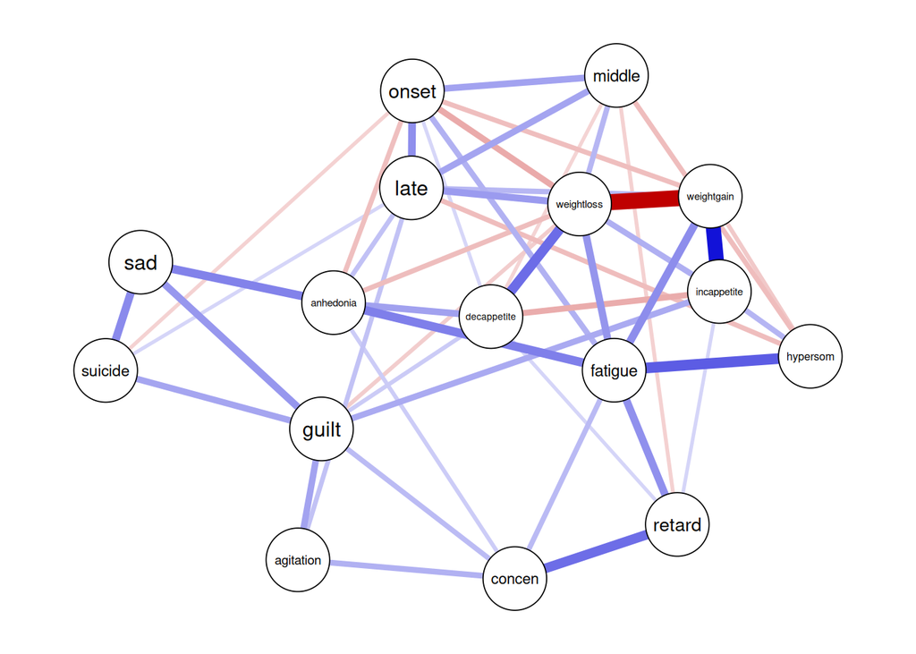

## モデル選択： 刈り込み

- psychonetricsパッケージのprune()関数を用いる。psychonetricsパッケージはパイプ演算子を使って可読性の高いコードが書きやすい

```r
ggm(data_dep) %>%
  runmodel %>%
  prune(alpha = 0.05) %>%
  getmatrix("omega") %>%
  qgraph(theme = "colorblind", cut = 0,layout = "spring",labels = node_names)
```

## モデル選択： 刈り込み

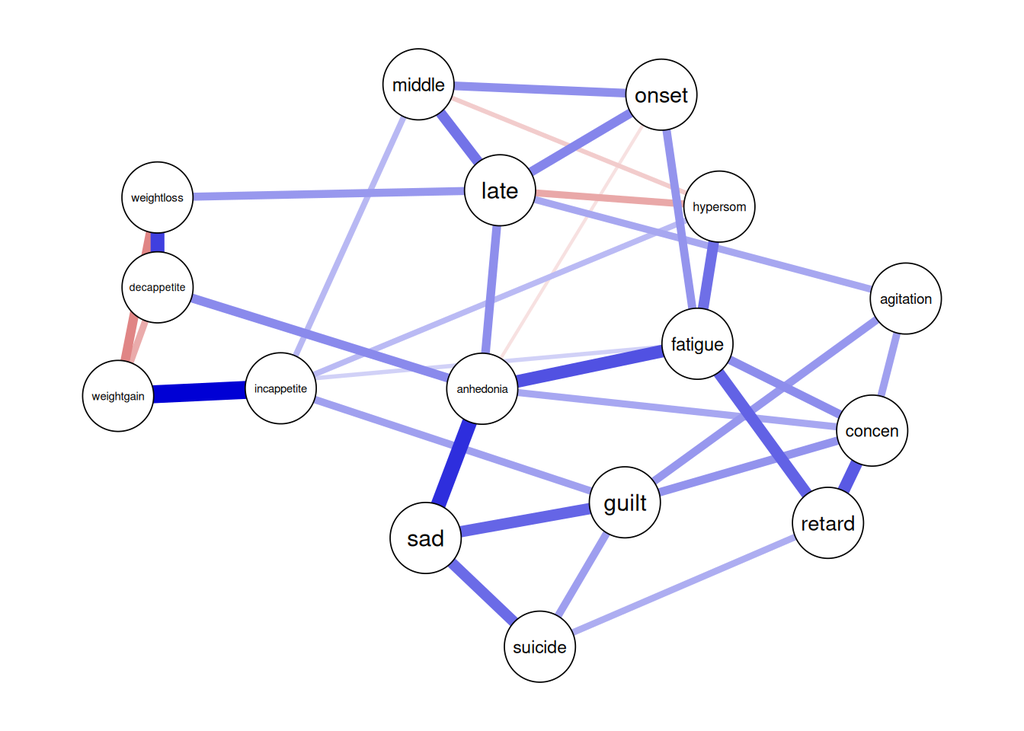

## モデル選択：モデル探索

- モデル探索はpsychonetricsパッケージのmodelsearch()で行う(モデル探索は計算に時間がかかることがある)

```r
ggm(data_dep) %>% runmodel %>%
  modelsearch(criterion = "bic") %>%
  getmatrix("omega") %>% qgraph(theme = "colorblind", cut = 0,layout = "spring",labels = node_names)
```

## モデル選択：モデル探索

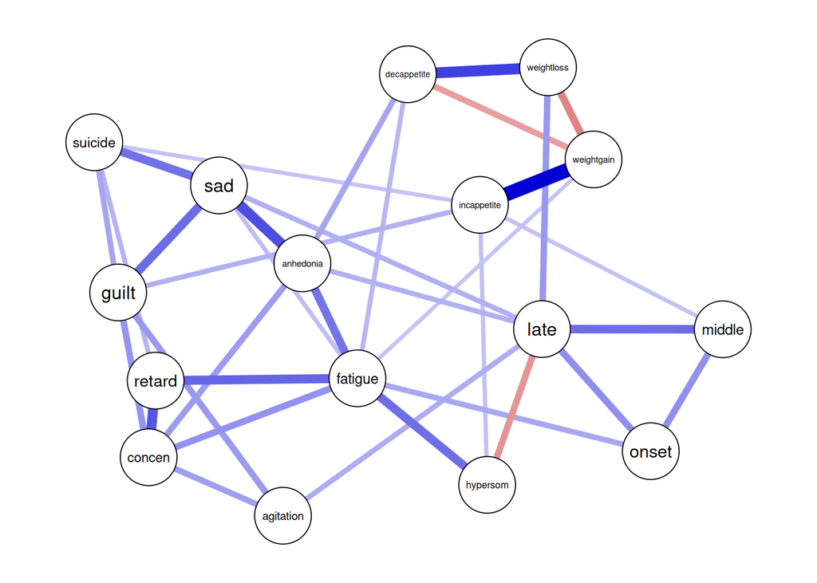

## モデル選択：正則化

- bootnetパッケージのestimateNetwork()関数を使って、EBICでパラメータ調整をするGLASSOを使う(「default=“EBICglasso”」を指定する）

```r
results_dep <- estimateNetwork(data_dep,default = "EBICglasso", corMethod = "cor_auto")
plot(results_dep, theme = "colorblind", cut = 0,layout = "spring",labels = node_names)
```

## モデル選択：正則化

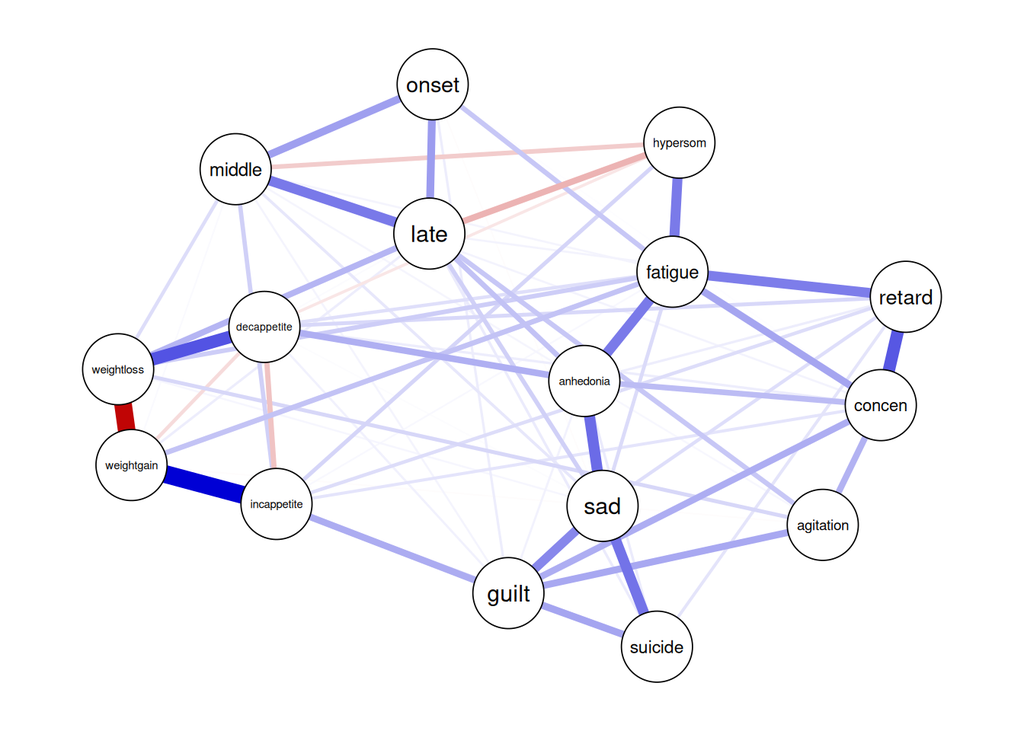

## エッジの重みの正確度

- bootnetパッケージのbootnet()関数を使う(なお、計算に時間がかかる)。summaryでも推定結果を確認できるが、プロットのほうが確認がしやすい
- ブートストラップ法によってブートストラップ信頼区間を計算してプロットできる。通常の信頼区間のように解釈できず（ゼロを跨ぐかで有意かどうか判断など）、あくまでエッジの重みのばらつきを視覚的に確認するために使う

```r
accuracy_edge <- bootnet(results_dep, nBoots = 2500, nCores =4, statistics =   c("edge", "strength", "closeness", "betweenness"))
plot(accuracy_edge, labels = FALSE, order = "sample")
```

## エッジの重みの正確度

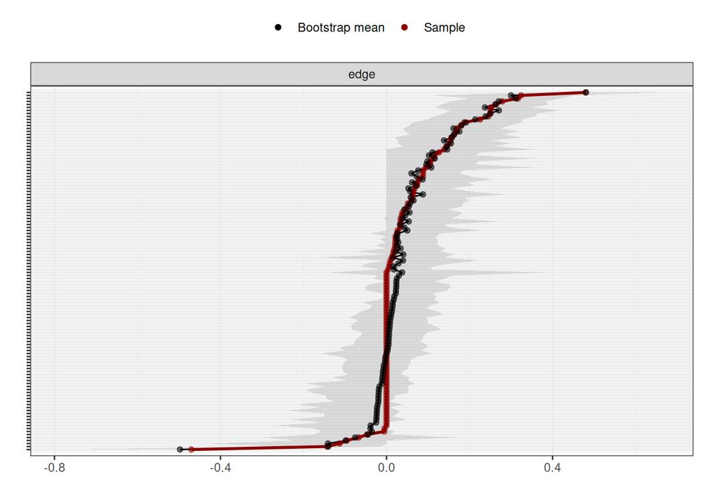

## 中心性指標のプロット

- qgraphパッケージのcontralityPlot関数でプロットできる。デフォルトではStrengthのみが出力されるので、includeで”Strength”, “Betweenness”, “Closeness”の３つを指定する

```r
centralityPlot(results_dep, include = c("Strength", "Betweenness", "Closeness"))
```

## 中心性指標のプロット

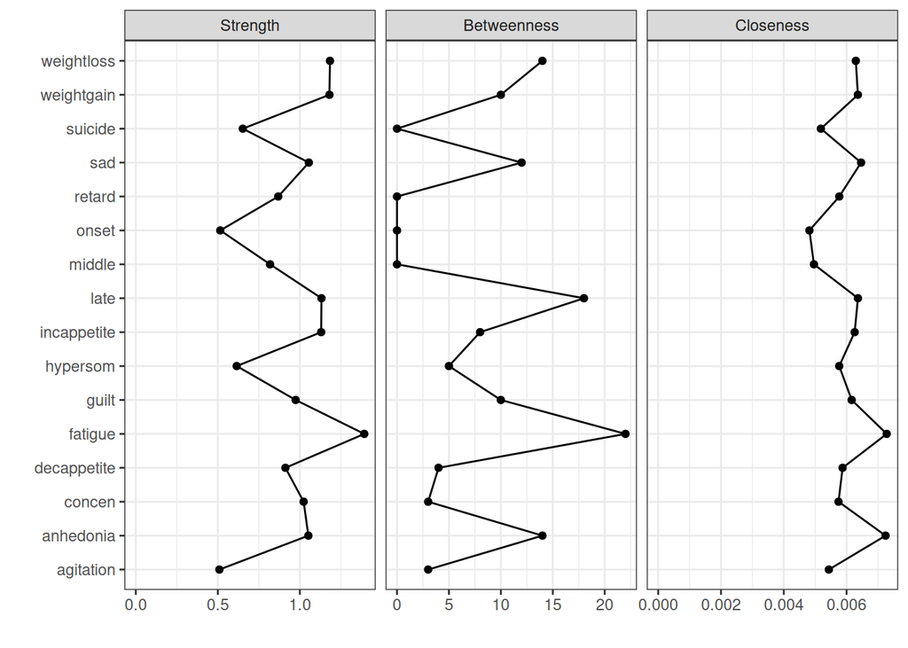

## 中心性指標の安定性

- bootnet()関数の「type = “case”」を指定して、ケースドロップ時の安定性を推定。statisticsで”strength”などを指定（計算に時間がかかる）
- サンプルサイズを徐々に減らした際の元のネットワークとの相関を検討

```r
stability_centrality <- bootnet(results_dep, nBoots = 2500, type = "case", nCores =4, statistics =  c("strength", "closeness", "betweenness"))
plot(stability_centrality, statistics = "strength")
plot(stability_centrality, statistics = "closeness")
plot(stability_centrality, statistics = "betweenness")
```

## 中心性指標の安定性(strength)

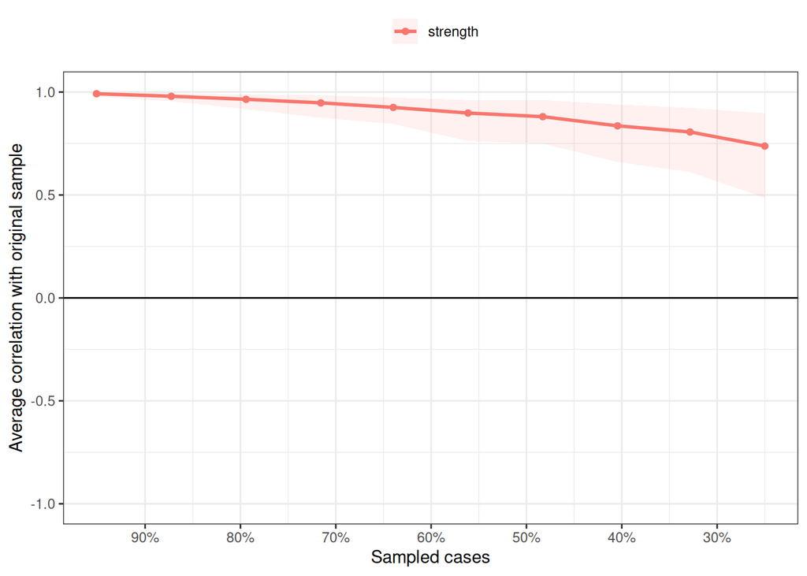

## 中心性指標の安定性(closeness)

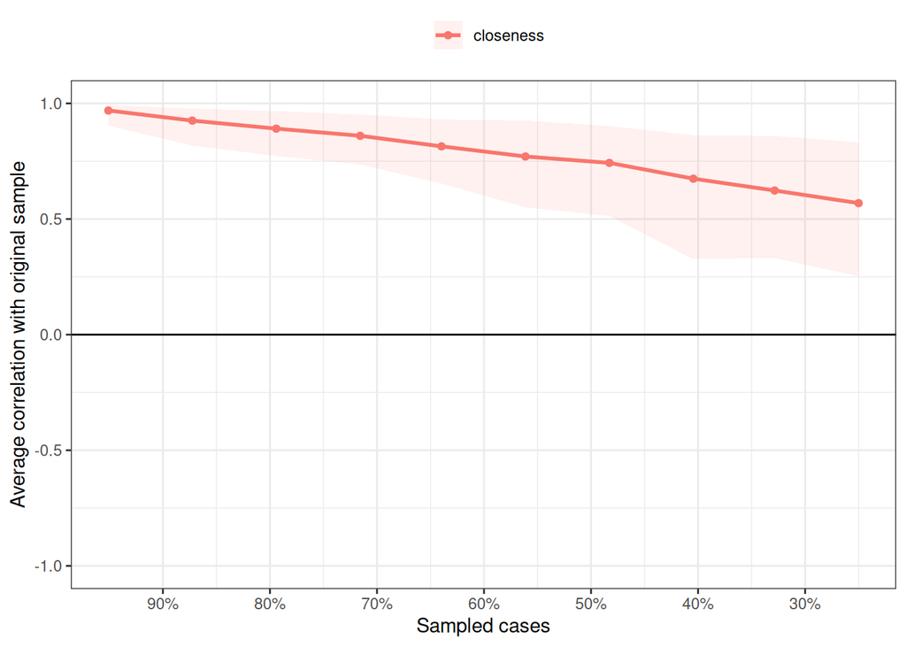

## 中心性指標の安定性(betweenness)

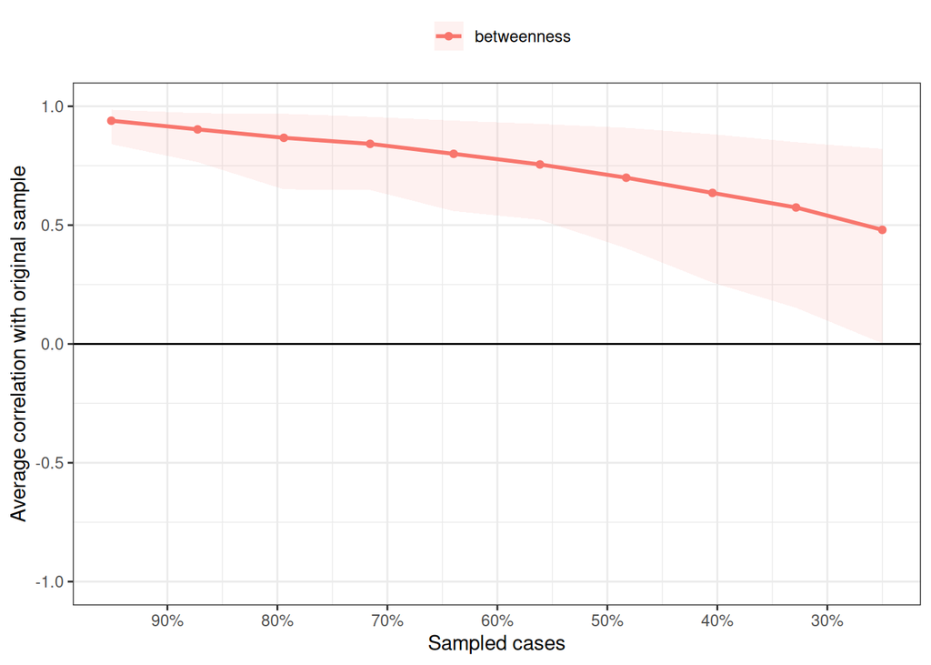

## CS係数の確認

- CS係数を確認すると、StrengthはCS係数が0.5を超えているが、ClosenessとBetweenessは低いので、解釈を控える必要がある

```r
corStability(stability_centrality)
```

＜以下抜粋＞

```
betweenness: 0.206

closeness: 0.284

strength: 0.596
```

## 有意差検定

- bootnetのdifferenceTest()関数を使う。fatigueとagitationのstrengthを比較すると有意な差がある
- 仮説がある場合は、このように検定できるが、プロットでエッジ間・ノード間の差を検討することもできる

```r
differenceTest(accuracy_edge, 14, 16, "strength")
```

```
Expected significance level given number of bootstrap samples is approximately: 0.05

id1       id2  measure     lower      upper significant

1 fatigue agitation strength -1.306443 -0.3789951        TRUE
```

## 有意差検定

- エッジ間の差の検定結果をプロットする(エッジ間で有意な差がある場合は黒く塗りつぶされ、有意ではない場合は灰色に塗りつぶされる)
- エッジの重み単体のブートストラップ信頼区間で有意差の検討はできないが、エッジの重みの差ならば有意性を検討できる

```r
plot(accuracy_edge, "edge", plot = "difference", onlyNonZero = TRUE, order = "sample")
```

## 有意差検定

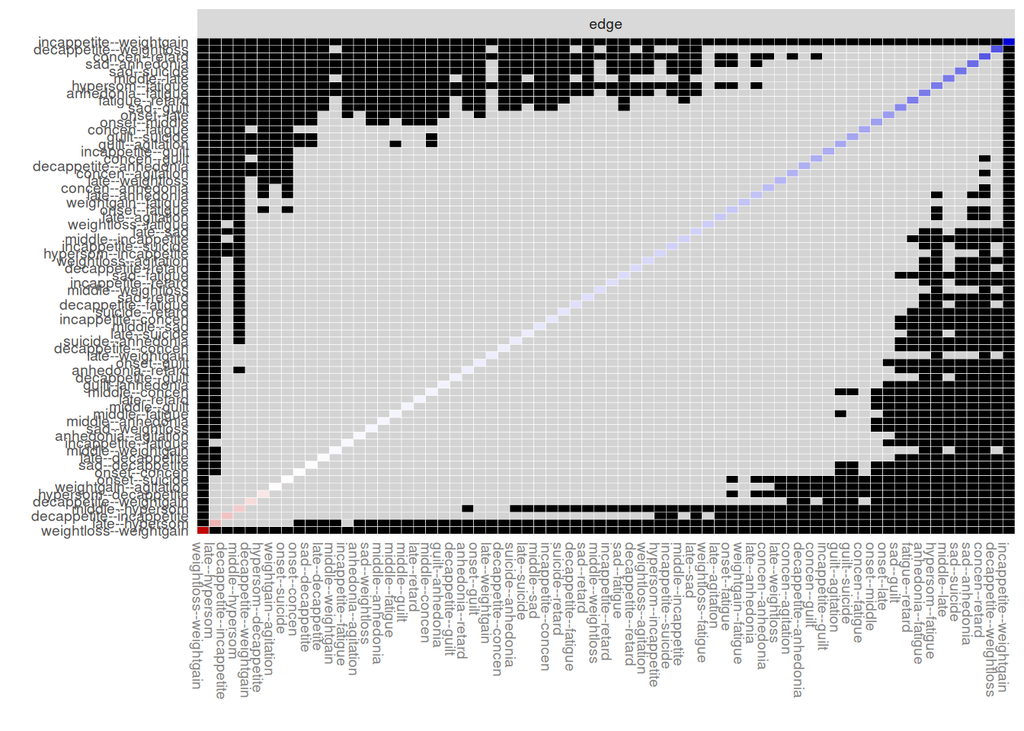

## 有意差検定

- Strengthにおけるノード間の差の検定結果をプロットする(ノード間で有意な差がある場合は黒色、有意ではない場合は灰色に塗りつぶす)

```r
plot(accuracy_edge,"strength")
```

## 有意差検定

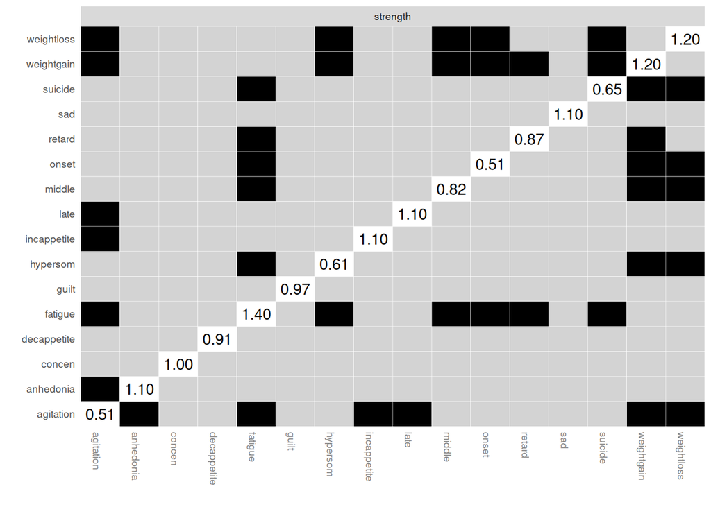

## 投入する変数とネットワーク構造

- ネットワーク構造は、含めるコンポーネントに依存する。ネットワークに含めるコンポーネントが変わるとどうなるのか？変数を減らした時のネットワークの見た目を比較する
- ６と７は食欲不振と増進、８と９は体重減少と増加になり、強めの負の関連を示すので、削除してみる。ここでは、７の食欲増進と９の体重増加を抜く

## 食欲増進と体重増加を除外

- 元々のデータでの推定・プロットとincappetite（食欲増進）とweightgain（体重増加）を除外したデータでの推定・プロットを比較する

```r
# 元データでの推定とプロット
results_dep <- estimateNetwork(data_dep,default = "EBICglasso", corMethod = "cor_auto")
plot(results_dep, theme = "colorblind", cut = 0,layout = "spring",labels = node_names)
# データを一部除外したプロット
data_dep2 <- data_dep %>%
  select(-incappetite, -weightgain)
node_names2 <- colnames(data_dep2)
results_dep2 <- estimateNetwork(data_dep2,default = "EBICglasso", corMethod = "cor_auto")
plot(results_dep2, theme = "colorblind", cut = 0,layout = "spring",labels = node_names2)
```

## ネットワークの比較

- 食欲不振と増進、体重減少と増加でクラスターを作っているようだったが見えなくなる

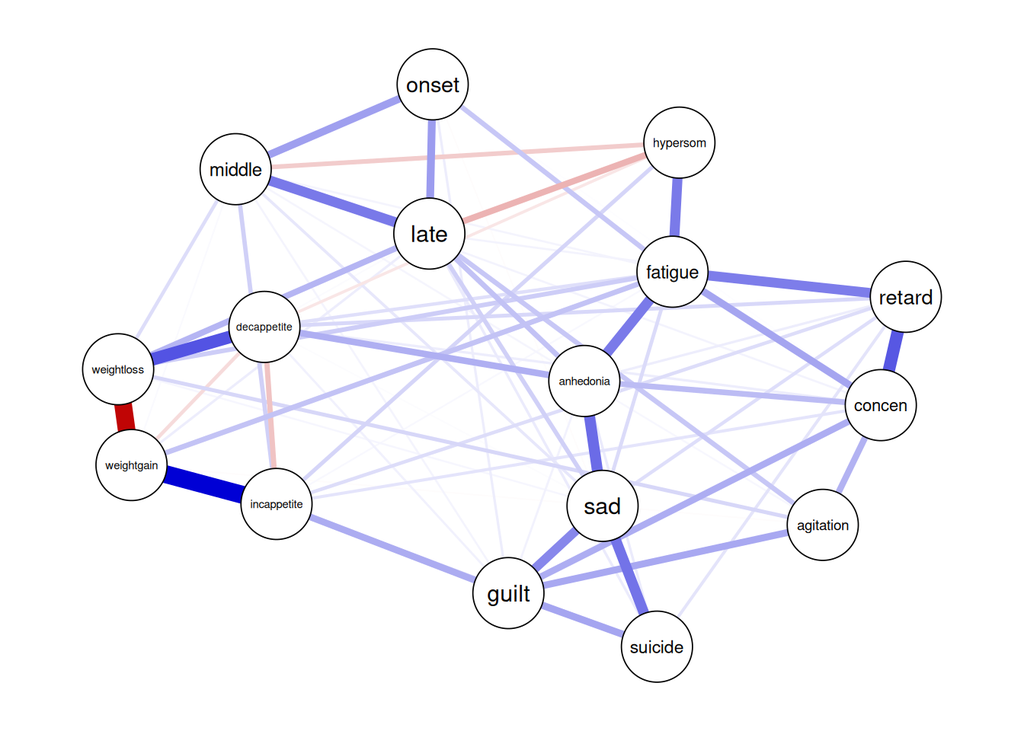

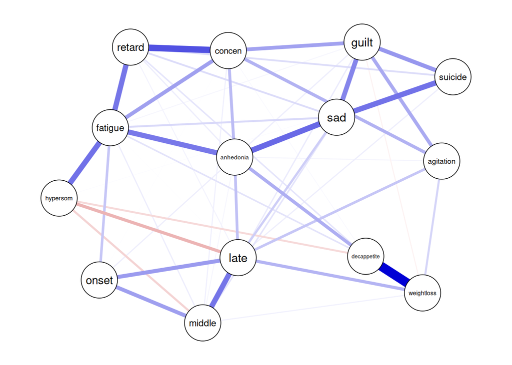